# `biblio-bridge`: a context-based literature linker with emergent knowledge identification.

T. J. Del Santo O’Neill

2025-06-13

## Concieving the idea

This application constructs a *context-based* similarity network from bibliographic data to evaluate citation bias<sup>1</sup> and to identify potential knowledge gaps or opportunities for cross-disciplinary research. Specifically, `BiblioBridge` develops a network in which nodes represent scholarly papers and edges denote their semantic similarity. This context-based network is then compared with a *citation-based* network, where nodes correspond to papers and edges represent their citation relationships.

**1.**That is, the tendency of authors to cite works based on their existing citation counts or perceived authority, rather than their actual contextual relevance to the citing content.

## Computational workflow

`biblio-bridge` is an interoperable framework with different modules written in distinct programming languages (*e.g.* `R` and/or `Python`), tailored to the specific task at hand, so that the advantages of each language are fully exploited. The end result would be a web app via `shiny` and deploy it via the cloud-based platform `shinyapps.io`.

- Module 1: fetching API data (`Python`-based);
- Module 2: NLP metrics (`Python`-based via `NLTK` and `spaCy`); and
- Module 3: data analysis and vis (`R`-based).

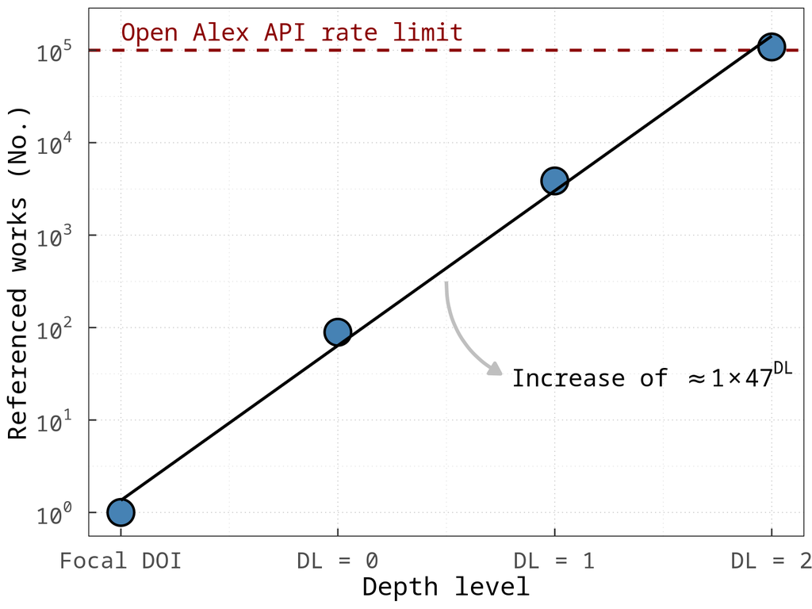

### Citation-based net at DL=2 by domain

[interactive chart not shown]